# Linear Regression in R

VENKATA SESHA SAI ESHWAR VUDHANTHI

2025-03-06

# Boston Dataset Analysis

## Objective

### How can we predict the median value of owner-cupled Homes using the Lowerstatus

#### We can figure out the middle price of homes where owners live using basic linear regression. We’ll use the percentage of people with lower status (lstat) to predict the middle home value (medv). We think there’s a negative link, which means when lstat goes up, home prices usually go down. To see how well lstat explains changes in home value, we’ll look at things like R-squared and Mean Squared Error (MSE). These numbers help us understand how accurate our model is.

### <What are we analysing? why? What insights can we gain from this analysis?

### We analyze the relationship between the percentage of lower-status population (LSTAT) and median home value (MEDV), to see if there is a significant effect of socio-economic status on housing prices, which can be useful for real estate market predictions, policy making and urban planning.

# Data Understand & Preperation

### <What kind of variables do we have? What potential questions could we answer further with this data?>

### The dataset includes different economic, social, and structural variables related to housing. Some questions we might ask are: - How do crime rates affect house prices? - Does the amount of non-retail business have an impact on home values? - How do property tax rates influence housing affordability?

# Data Exploration

```r
library(ISLR2)
data(Boston)
glimpse(Boston)
```

```
## Rows: 506
## Columns: 13
## $ crim    <dbl> 0.00632, 0.02731, 0.02729, 0.03237, 0.06905, 0.02985, 0.08829,…
## $ zn      <dbl> 18.0, 0.0, 0.0, 0.0, 0.0, 0.0, 12.5, 12.5, 12.5, 12.5, 12.5, 1…
## $ indus   <dbl> 2.31, 7.07, 7.07, 2.18, 2.18, 2.18, 7.87, 7.87, 7.87, 7.87, 7.…
## $ chas    <int> 0, 0, 0, 0, 0, 0, 0, 0, 0, 0, 0, 0, 0, 0, 0, 0, 0, 0, 0, 0, 0,…
## $ nox     <dbl> 0.538, 0.469, 0.469, 0.458, 0.458, 0.458, 0.524, 0.524, 0.524,…
## $ rm      <dbl> 6.575, 6.421, 7.185, 6.998, 7.147, 6.430, 6.012, 6.172, 5.631,…
## $ age     <dbl> 65.2, 78.9, 61.1, 45.8, 54.2, 58.7, 66.6, 96.1, 100.0, 85.9, 9…
## $ dis     <dbl> 4.0900, 4.9671, 4.9671, 6.0622, 6.0622, 6.0622, 5.5605, 5.9505…
## $ rad     <int> 1, 2, 2, 3, 3, 3, 5, 5, 5, 5, 5, 5, 5, 4, 4, 4, 4, 4, 4, 4, 4,…
## $ tax     <dbl> 296, 242, 242, 222, 222, 222, 311, 311, 311, 311, 311, 311, 31…
## $ ptratio <dbl> 15.3, 17.8, 17.8, 18.7, 18.7, 18.7, 15.2, 15.2, 15.2, 15.2, 15…
## $ lstat   <dbl> 4.98, 9.14, 4.03, 2.94, 5.33, 5.21, 12.43, 19.15, 29.93, 17.10…
## $ medv    <dbl> 24.0, 21.6, 34.7, 33.4, 36.2, 28.7, 22.9, 27.1, 16.5, 18.9, 15…
```

```r
summary(Boston)
```

```
##       crim                zn             indus            chas
##  Min.   : 0.00632   Min.   :  0.00   Min.   : 0.46   Min.   :0.00000
##  1st Qu.: 0.08205   1st Qu.:  0.00   1st Qu.: 5.19   1st Qu.:0.00000
##  Median : 0.25651   Median :  0.00   Median : 9.69   Median :0.00000
##  Mean   : 3.61352   Mean   : 11.36   Mean   :11.14   Mean   :0.06917
##  3rd Qu.: 3.67708   3rd Qu.: 12.50   3rd Qu.:18.10   3rd Qu.:0.00000
##  Max.   :88.97620   Max.   :100.00   Max.   :27.74   Max.   :1.00000
##       nox               rm             age              dis
##  Min.   :0.3850   Min.   :3.561   Min.   :  2.90   Min.   : 1.130
##  1st Qu.:0.4490   1st Qu.:5.886   1st Qu.: 45.02   1st Qu.: 2.100
##  Median :0.5380   Median :6.208   Median : 77.50   Median : 3.207
##  Mean   :0.5547   Mean   :6.285   Mean   : 68.57   Mean   : 3.795
##  3rd Qu.:0.6240   3rd Qu.:6.623   3rd Qu.: 94.08   3rd Qu.: 5.188
##  Max.   :0.8710   Max.   :8.780   Max.   :100.00   Max.   :12.127
##       rad              tax           ptratio          lstat
##  Min.   : 1.000   Min.   :187.0   Min.   :12.60   Min.   : 1.73
##  1st Qu.: 4.000   1st Qu.:279.0   1st Qu.:17.40   1st Qu.: 6.95
##  Median : 5.000   Median :330.0   Median :19.05   Median :11.36
##  Mean   : 9.549   Mean   :408.2   Mean   :18.46   Mean   :12.65
##  3rd Qu.:24.000   3rd Qu.:666.0   3rd Qu.:20.20   3rd Qu.:16.95
##  Max.   :24.000   Max.   :711.0   Max.   :22.00   Max.   :37.97
##       medv
##  Min.   : 5.00
##  1st Qu.:17.02
##  Median :21.20
##  Mean   :22.53
##  3rd Qu.:25.00
##  Max.   :50.00
```

```r
missing_values = Boston %>%
  summarise(across(everything(), ~ sum(is.na(.))))
print(missing_values)
```

```
##   crim zn indus chas nox rm age dis rad tax ptratio lstat medv
## 1    0  0     0    0   0  0   0   0   0   0       0     0    0
```

# Train-Test Split

<How does this technique aid our analysis, espicially given new data?>

### Splitting data into training and testing sets ensures that our model can generalize to unseen data. It prevents overfitting and provides a reliable measure of model performance.

```r
set.seed(123) # For reproductibility
Boston_split = Boston %>%
  mutate(id = row_number()) %>%
  sample_frac(0.75)

Boston = Boston %>% mutate(id = row_number())

train_data = Boston_split
test_data = anti_join(Boston, Boston_split, by = "id") #Remaining 25%
```

# Exploratory Data Analysis

#### <What figures did we build? why? What information do they convey? How is it important to the analysis?>

### We built histograms and scatterplots to understand data distribution and relationships.

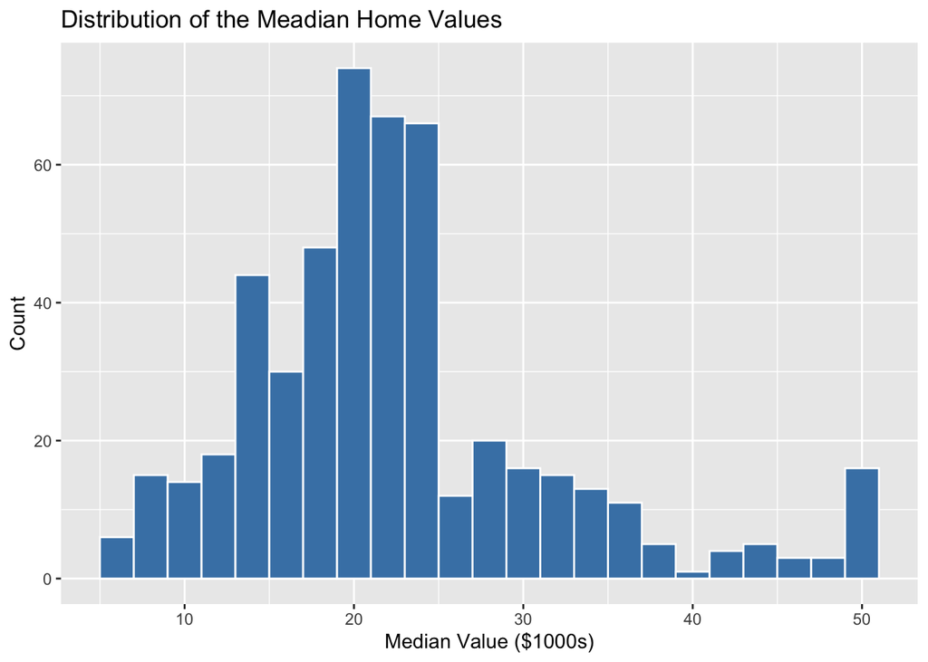

```r
ggplot(Boston, aes(x = medv)) +
  geom_histogram(fill = "steelblue", binwidth =2, color = "white") +
  labs(title = "Distribution of the Meadian Home Values",
       x = "Median Value ($1000s)",
       y = "Count")
```

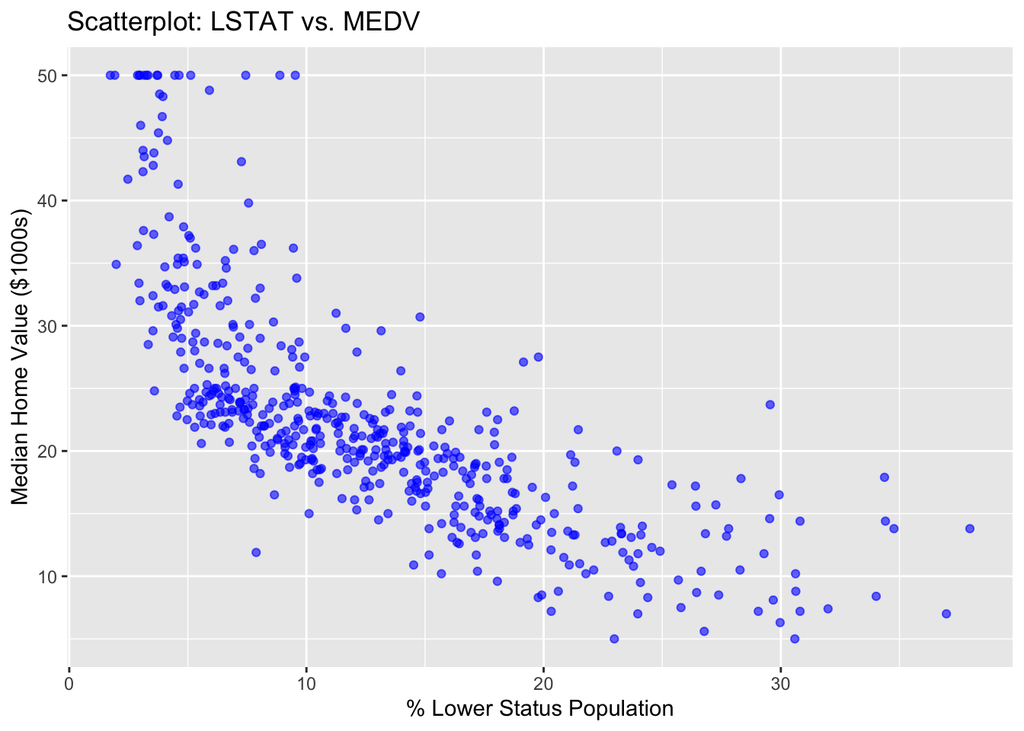

```r
ggplot(Boston, aes(x = lstat, y=medv)) +
  geom_point(alpha = 0.6, color = "blue") +
  labs(title = "Scatterplot: LSTAT vs. MEDV",
       x = "% Lower Status Population",
       y = "Median Home Value ($1000s)")
```

# Model Implementation & Explaination

### < what model are we using? why does this/these model(s) apply to the data? What are the pros and cons of this type of model?>

### We are using linear regression because it helps quantify the relationship between LSTAT and MEDV. Pros: simple to interpret, computationally efficient. Cons: assumes linearity, sensitive to outliers.

### Perform simple Liner Regression on Training Data

```r
lm.fit = lm(medv ~ lstat, data = train_data)
summary(lm.fit)
```

```
##
## Call:
## lm(formula = medv ~ lstat, data = train_data)
##
## Residuals:
##     Min      1Q  Median      3Q     Max
## -15.068  -3.891  -1.275   1.706  24.613
##
## Coefficients:
##             Estimate Std. Error t value Pr(>|t|)
## (Intercept) 34.51650    0.62851   54.92   <2e-16 ***
## lstat       -0.95795    0.04357  -21.99   <2e-16 ***
## ---
## Signif. codes:  0 '***' 0.001 '**' 0.01 '*' 0.05 '.' 0.1 ' ' 1
##
## Residual standard error: 6.131 on 378 degrees of freedom
## Multiple R-squared:  0.5612, Adjusted R-squared:  0.5601
## F-statistic: 483.5 on 1 and 378 DF,  p-value: < 2.2e-16
```

# Apply Model to Test Data

```r
train_mse = mean((train_data$medv - predict(lm.fit, train_data))^2)
test_mse = mean((test_data$medv - predict(lm.fit, test_data))^2)

print(paste("Training MSE:", round(train_mse, 2)))
```

```
## [1] "Training MSE: 37.39"
```

```r
print(paste("Test MSE:", round(test_mse, 2)))
```

```
## [1] "Test MSE: 41.86"
```

# Simple Linear Regression Results & Interpritaion

### <Overall, how good is this fit? What does it say about the data and the question being asked?>

### If the test MSE is low, it indicates a strong predictive ability. If high, other variables may influence MEDV beyond LSTAT.

# Perform Multiple Linear Regression on Trainign Data

### <What question does this model answer?>

### This model investigates how multiple factors (LSTAT and AGE) impact home prices.

```r
lm.multiple.fit = lm(medv ~ lstat + age, data = train_data)
summary(lm.multiple.fit)
```

```
##
## Call:
## lm(formula = medv ~ lstat + age, data = train_data)
##
## Residuals:
##     Min      1Q  Median      3Q     Max
## -15.925  -3.725  -1.214   1.788  23.201
##
## Coefficients:
##             Estimate Std. Error t value Pr(>|t|)
## (Intercept) 33.12191    0.81744  40.519  < 2e-16 ***
## lstat       -1.04394    0.05414 -19.284  < 2e-16 ***
## age          0.03625    0.01374   2.639  0.00867 **
## ---
## Signif. codes:  0 '***' 0.001 '**' 0.01 '*' 0.05 '.' 0.1 ' ' 1
##
## Residual standard error: 6.083 on 377 degrees of freedom
## Multiple R-squared:  0.5692, Adjusted R-squared:  0.5669
## F-statistic:   249 on 2 and 377 DF,  p-value: < 2.2e-16
```

# Apply the Model to Test Data

```r
train_mse = mean((train_data$medv - predict(lm.multiple.fit, train_data))^2)
test_mse = mean((test_data$medv - predict(lm.multiple.fit, test_data))^2)

print(paste("Training MSE:", round(train_mse, 2)))
```

```
## [1] "Training MSE: 36.72"
```

```r
print(paste("Test MSE:", round(test_mse, 2)))
```

```
## [1] "Test MSE: 41.49"
```

## Multiple Linear Regression Results & Interpritaion

### Comparing the test MSE of simple vs. multiple regression helps determine if adding AGE improves predictions.

# NHANES Data Analysis

## Objective

### Please predict BMI using Age, SmaokeNow, PhysActive for individuals between the ages of 18 and 70

# Data Understanding & Preperation

## Data Loading

```r
#install.packages("NHANES")
library(NHANES)
library(tidyverse)
data(NHANES)

SMOKERS = NHANES %>%
  select(BMI, Age, SmokeNow, PhysActive) %>%
  filter(Age >= 18 & Age <= 70)
```

# Cheking for missing values

```r
missing_values <- SMOKERS %>%
  summarise(across(everything(), ~ sum(is.na(.))))
print(missing_values)
```

```
## # A tibble: 1 × 4
##     BMI   Age SmokeNow PhysActive
##   <int> <int>    <int>      <int>
## 1    47     0     3868          0
```

# Removing rows with missing values

```r
SMOKERS <- drop_na(SMOKERS)
```

# Train-Test Split (75% training, 25% testing)

```r
set.seed(123)
NHANES_split <- SMOKERS %>%
  mutate(id = row_number()) %>%
  sample_frac(0.75)

SMOKERS <- SMOKERS %>% mutate(id = row_number())

train_data <- NHANES_split
test_data <- anti_join(SMOKERS, NHANES_split, by = "id")
```

# Exploratory Data Analysis

# Histogram of BMI distribution

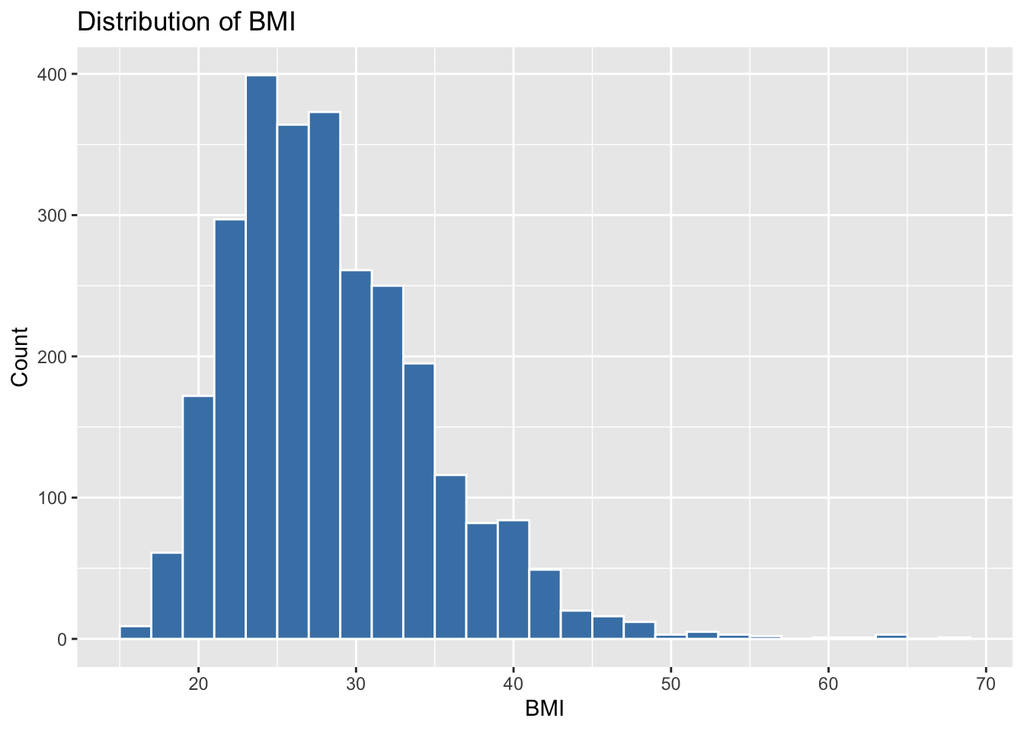

```r
ggplot(SMOKERS, aes(x = BMI)) +
  geom_histogram(fill = "steelblue", binwidth = 2, color = "white") +
  labs(title = "Distribution of BMI",
       x = "BMI",
       y = "Count")
```

# Scatterplot of Age vs BMI

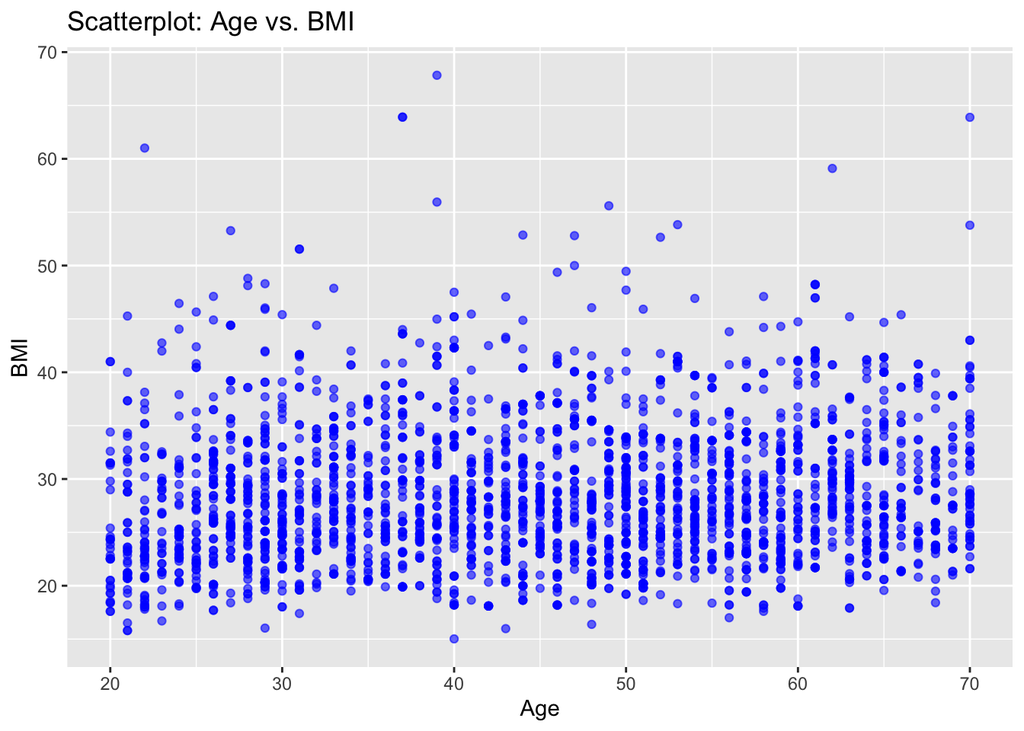

```r
ggplot(SMOKERS, aes(x = Age, y = BMI)) +
  geom_point(alpha = 0.6, color = "blue") +
  labs(title = "Scatterplot: Age vs. BMI",
       x = "Age",
       y = "BMI")
```

# Model Implementation - Simple Linear Regression

```r
lm.fit <- lm(BMI ~ Age, data = train_data)
summary(lm.fit)
```

```
##
## Call:
## lm(formula = BMI ~ Age, data = train_data)
##
## Residuals:
##     Min      1Q  Median      3Q     Max
## -13.372  -4.730  -1.227   3.537  39.489
##
## Coefficients:
##             Estimate Std. Error t value Pr(>|t|)
## (Intercept) 26.34264    0.48636  54.163  < 2e-16 ***
## Age          0.05123    0.01033   4.962 7.55e-07 ***
## ---
## Signif. codes:  0 '***' 0.001 '**' 0.01 '*' 0.05 '.' 0.1 ' ' 1
##
## Residual standard error: 6.559 on 2082 degrees of freedom
## Multiple R-squared:  0.01169,    Adjusted R-squared:  0.01121
## F-statistic: 24.62 on 1 and 2082 DF,  p-value: 7.554e-07
```

# Applying Model to Test Data

```r
train_mse <- mean((train_data$BMI - predict(lm.fit, train_data))^2)
test_mse <- mean((test_data$BMI - predict(lm.fit, test_data))^2)

print(paste("Training MSE:", round(train_mse, 2)))
```

```
## [1] "Training MSE: 42.98"
```

```r
print(paste("Test MSE:", round(test_mse, 2)))
```

```
## [1] "Test MSE: 34.98"
```

# Multiple Linear Regression (Using Age, SmokeNow, and PhysActive)

```r
lm.multiple.fit <- lm(BMI ~ Age + SmokeNow + PhysActive, data = train_data)
summary(lm.multiple.fit)
```

```
##
## Call:
## lm(formula = BMI ~ Age + SmokeNow + PhysActive, data = train_data)
##
## Residuals:
##     Min      1Q  Median      3Q     Max
## -13.947  -4.657  -1.163   3.773  37.554
##
## Coefficients:
##               Estimate Std. Error t value Pr(>|t|)
## (Intercept)   29.12894    0.60570  48.091  < 2e-16 ***
## Age            0.02941    0.01066   2.759  0.00586 **
## SmokeNowYes   -1.31892    0.29995  -4.397 1.15e-05 ***
## PhysActiveYes -2.32454    0.29222  -7.955 2.92e-15 ***
## ---
## Signif. codes:  0 '***' 0.001 '**' 0.01 '*' 0.05 '.' 0.1 ' ' 1
##
## Residual standard error: 6.454 on 2080 degrees of freedom
## Multiple R-squared:  0.04406,    Adjusted R-squared:  0.04268
## F-statistic: 31.96 on 3 and 2080 DF,  p-value: < 2.2e-16
```

# Applying Multiple Regression Model to Test Data

```r
train_mse_multi <- mean((train_data$BMI - predict(lm.multiple.fit, train_data))^2)
test_mse_multi <- mean((test_data$BMI - predict(lm.multiple.fit, test_data))^2)

print(paste("Training MSE (Multiple Regression):", round(train_mse_multi, 2)))
```

```
## [1] "Training MSE (Multiple Regression): 41.57"
```

```r
print(paste("Test MSE (Multiple Regression):", round(test_mse_multi, 2)))
```

```
## [1] "Test MSE (Multiple Regression): 33.69"
```